# Herring Landings Report for 2024 Fishing Season

Herring & Fisheries Acoustics Working Group - SABS

2024-06-24

# Landing Report Subtypes

All data are subject to changes and are generated from data uploaded to MARFIS and the Herring Sampling database. Note that quality control checks are performed throughout the season. Some coordinates of landings may be inaccurate

## Purse Seine Landings

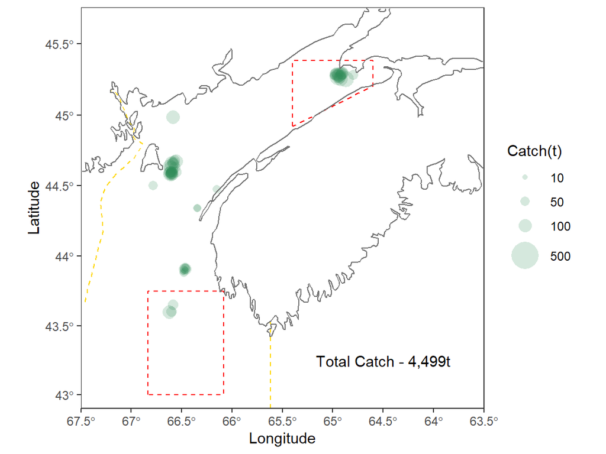

Figure 1. Overall purse seine catches in quota area.

[figure not shown]

Figure 2. Overall purse seine offshore banks non-quota catches.

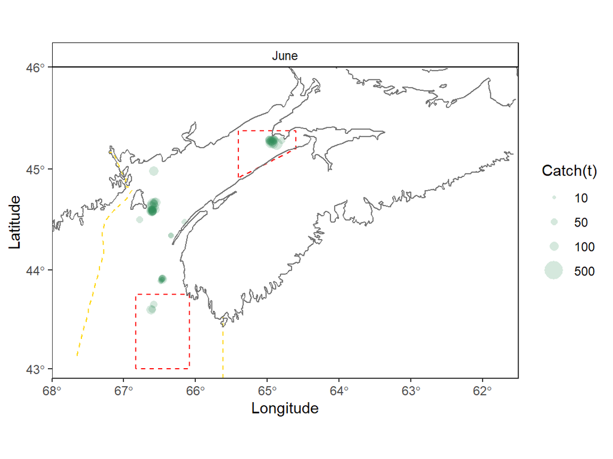

Figure 3. Purse seine Landings by month.

## Fishing Grounds

### German Bank

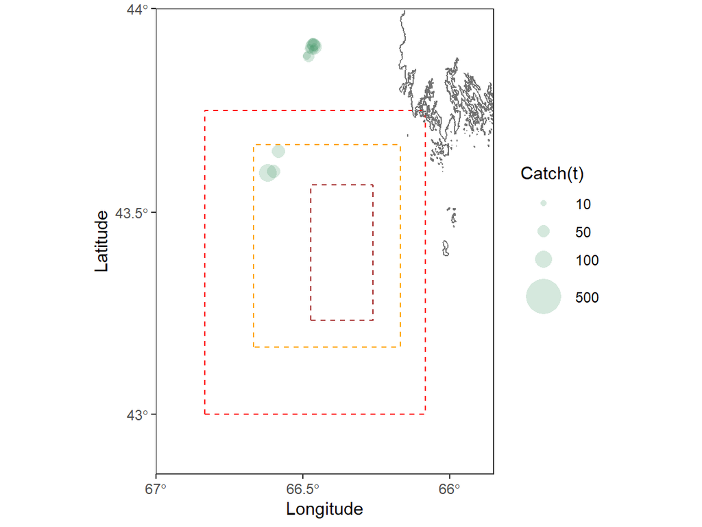

Figure 4. Purse seine catches for German Bank Fishery.

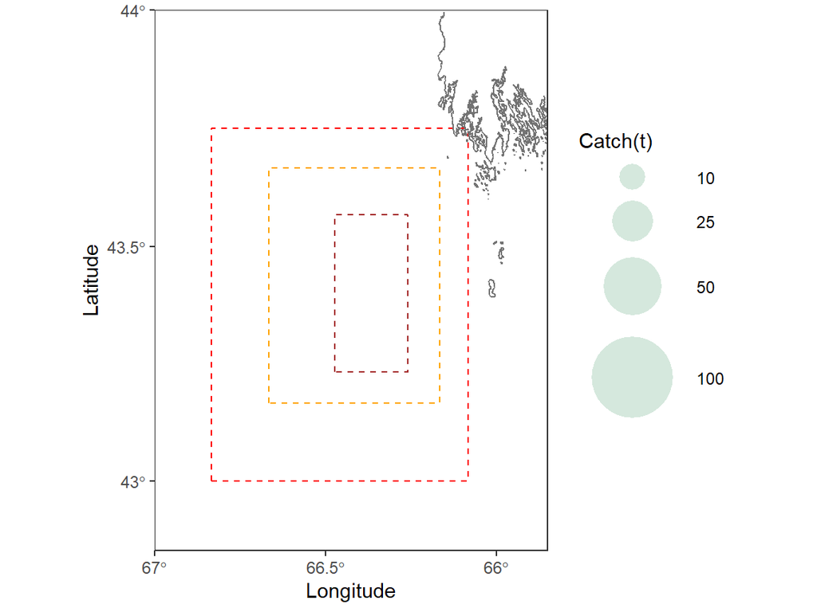

Figure 5. Gillnet catches for german Bank Fishery.

### Scots Bay

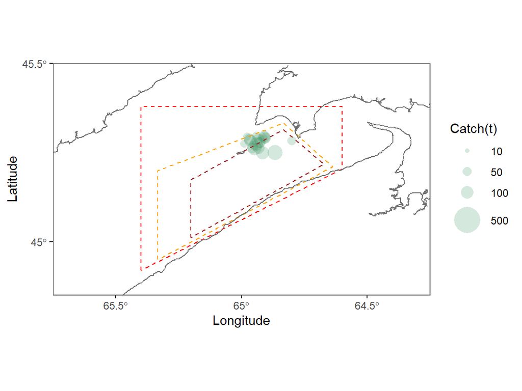

Figure 6. Purse seine catches for Scots Bay Fishery.

### Little Hope

[figure not shown]

Figure 7. Little Hope Gillnet Catches.

### Eastern Shore

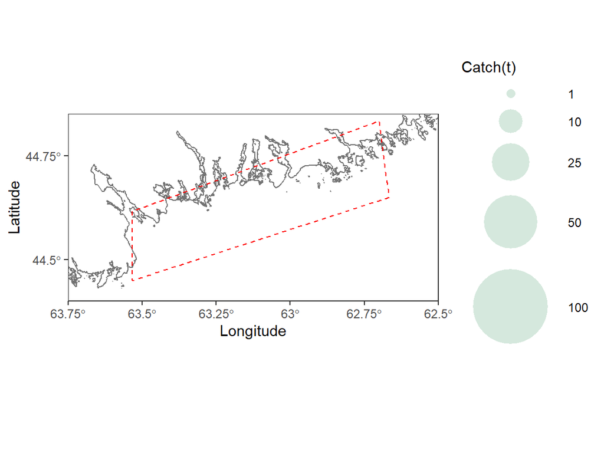

Figure 8. Eastern Shore Gillnet Catches.

### New Brunswick Southwest

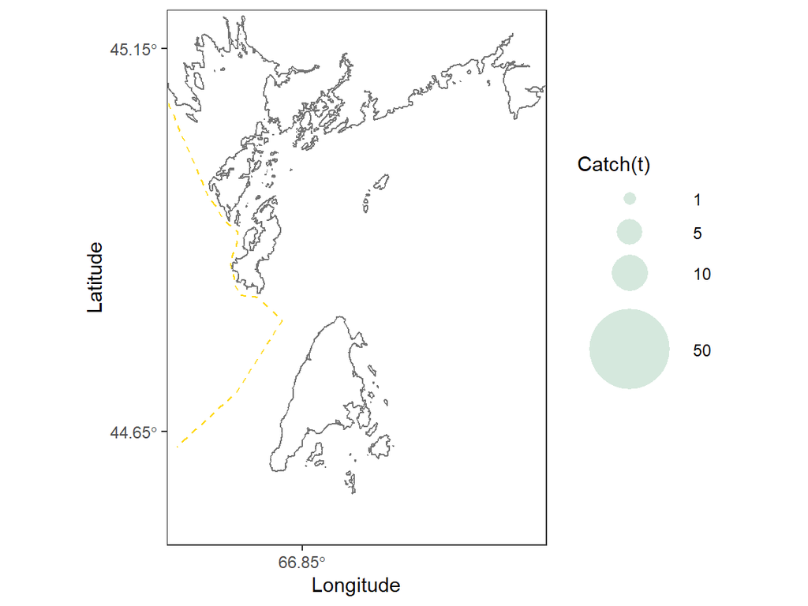

Figure 9. Weir Catches for calendar Year (reported by industry).

## Length Frequency Stats

### Overall

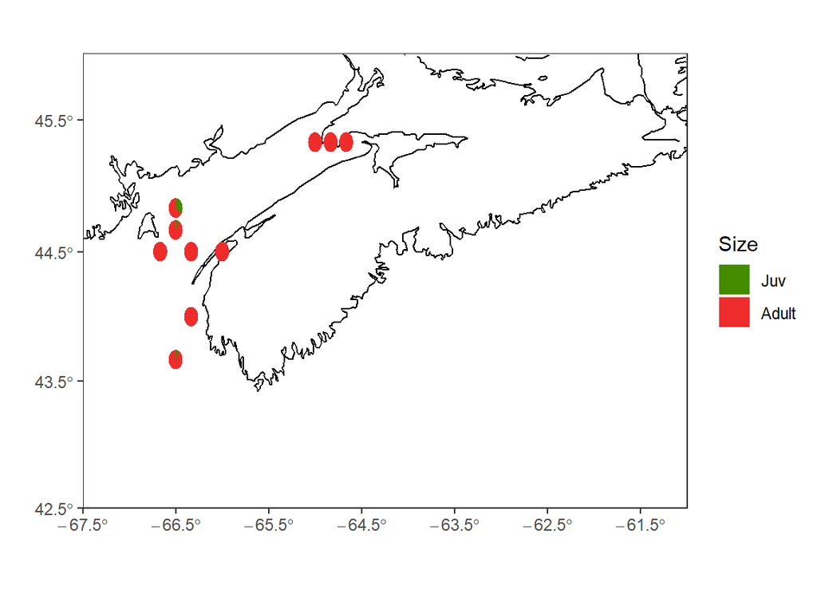

Figure 11. Overall herring sampling catch coverage by 10 mile squares. Pie charts show samples size proportions for juvenile (green <23cm) and adult herring (red >=23cm).

### Gear

[figure not shown]

Figure 12. Herring length frequency samples by gear.

[figure not shown]

Figure 13. Herring length frequency samples by gear by month.

### Fishing Ground

[figure not shown]

Figure 14. Herring length frequency samples by fishing ground.

### Fishing Ground by month

[figure not shown]

Figure 15. Herring length frequency samples by fishing ground by month.

## Landing Statistics

### Table 1

Table 1: Herring landings by area, gear, and month

[output not shown]

| Complex | Area | Gear | Jan | Feb | Mar | Apr | May | Jun | Jul | Aug | Sep | Oct | Nov | Dec | Total |
| --- | --- | --- | --- | --- | --- | --- | --- | --- | --- | --- | --- | --- | --- | --- | --- |
| SWNS/BoF | 4X | Purse seine | 0 | 0 | 0 | 0 | 0 | 4499 | 0 | 0 | 0 | 0 | 0 | 0 | 4499 |
| SWNS/BoF | 4X | Weir | 0 | 0 | 0 | 50 | 0 | 0 | 0 | 0 | 0 | 0 | 0 | 0 | 50 |
| Coastal | Eastern Shore | Danish seine | 0 | 0 | 0 | 0 | 0 | 0 | 0 | 0 | 0 | 0 | 0 | 0 | 0 |
| Offshore | Offshore | Danish seine | 0 | 0 | 0 | 0 | 0 | 0 | 0 | 0 | 0 | 0 | 0 | 0 | 0 |
| All | 4VWX |  | 0 | 0 | 0 | 50 | 0 | 4499 | 0 | 0 | 0 | 0 | 0 | 0 | 4550 |

### Table 2

Table 2: Herring length sampling summary by month, gear and fishing ground with average weight, mean length and length range by grouping. Data for number of samples, number of fish measured, sampled catch weight (t) and estimated catch numbers (thousands) for the sampled catch. Average weight is based on sampled catch and the estimated sampled catch numbers.

[output not shown]

| Month | Gear | Fishing Ground | No. Samp. | No. Meas. | Cat. Samp.(t) | Cat. No.(1000s) | Avg. Wt.(g) | Min. Len. | Avg. Len. | Max. Len. |
| --- | --- | --- | --- | --- | --- | --- | --- | --- | --- | --- |
| June | Purse Seine | Gannet Dry Ledge | 4 | 747 | 168 | 1,200 | 140.0 | 18.5 | 26.6 | 31.0 |
| June | Purse Seine | Grand Manan | 48 | 8,852 | 2,152 | 14,746 | 145.9 | 17.0 | 26.9 | 33.0 |
| June | Purse Seine | Grand Manan Banks | 2 | 351 | 48 | 299 | 160.7 | 24.5 | 27.8 | 31.0 |
| June | Purse Seine | Long Island | 6 | 1,077 | 101 | 650 | 155.4 | 23.0 | 27.5 | 32.5 |
| June | Purse Seine | Scots Bay | 40 | 7,348 | 1,783 | 11,563 | 154.2 | 23.0 | 27.4 | 32.5 |
| June | Purse Seine | Trinity | 12 | 2,288 | 379 | 2,710 | 139.8 | 22.0 | 26.5 | 32.0 |

### Table 3

Table 3: Herring length sampling summary by month, gear and fishing ground with percent catch numbers by size groups for <15cm (~6 inch), <18cm (~7 inch), <23cm and >=23cm (adult). Data for the number of samples, sampled catch weight (t), estimated catch weight (t) <23cm and estimated catch numbers (thousands) for the sampled catch. Average weight is based on sampled catch and the estimated sampled catch numbers.

[output not shown]

| Month | Gear | Fishing Ground | No. Samp. | No. Meas. | Cat. Samp.(t) | Catch t <23cm | No. <LT 15cm | No. <LT 18cm | %Adult >=23cm | %Adult >=30cm |
| --- | --- | --- | --- | --- | --- | --- | --- | --- | --- | --- |
| 6 | Purse Seine | Gannet Dry Ledge | 4 | 168 | 1 | 0 | 0.0 | 0.7 | 99.3 | 0.1 |
| 6 | Purse Seine | Grand Manan | 48 | 2,152 | 22 | 0 | 0.1 | 1.7 | 98.3 | 2.6 |
| 6 | Purse Seine | Grand Manan Banks | 2 | 48 | 0 | 0 | 0.0 | 0.0 | 100.0 | 3.4 |
| 6 | Purse Seine | Long Island | 6 | 101 | 0 | 0 | 0.0 | 0.0 | 100.0 | 3.2 |
| 6 | Purse Seine | Scots Bay | 40 | 1,783 | 0 | 0 | 0.0 | 0.0 | 100.0 | 1.6 |
| 6 | Purse Seine | Trinity | 12 | 379 | 0 | 0 | 0.0 | 0.0 | 100.0 | 0.6 |

## About

This report was generated on: 2024-06-24 12:46:06  
R version 4.2.0 Patched (2022-05-30 r82437 ucrt)